# Bayesian GLM Part3

Author

Murray Logan

Published

09/09/2025

# 1 Preparations

Load the necessary libraries

```r
library(tidyverse) # for data wrangling etc
library(rstanarm) # for fitting models in STAN
library(cmdstanr) # for cmdstan
library(brms) # for fitting models in STAN
library(coda) # for diagnostics
library(bayesplot) # for diagnostics
library(ggmcmc) # for MCMC diagnostics
library(DHARMa) # for residual diagnostics
library(rstan) # for interfacing with STAN
library(emmeans) # for marginal means etc
library(broom) # for tidying outputs
library(tidybayes) # for more tidying outputs
library(ggeffects) # for partial plots
library(broom.mixed) # for summarising models
library(ggeffects) # for partial effects plots
library(bayestestR) # for ROPE
library(see) # for some plots
library(easystats) # for the easystats ecosystem
library(INLA) # for approximate Bayes
library(INLAutils) # for additional INLA outputs
library(patchwork) # for multiple plots
library(modelsummary) # for data and model summaries
theme_set(theme_grey()) # put the default ggplot theme back
source("helperFunctions.R")
```

# 2 Scenario

Here is a modified example from Peake and Quinn (1993). Peake and Quinn (1993) investigated the relationship between the number of individuals of invertebrates living in amongst clumps of mussels on a rocky intertidal shore and the area of those mussel clumps.

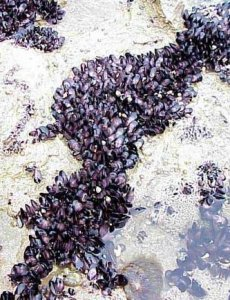

**Figure** 1: Mussels

**Table** 1: Format of peakquinn.csv data files

| AREA | INDIV |
| --- | --- |
| 516.00 | 18 |
| 469.06 | 60 |
| 462.25 | 57 |
| 938.60 | 100 |
| 1357.15 | 48 |
| ... | ... |

**Table** 2: Description of the variables in the peakquinn data file

| **AREA** | Area of mussel clump mm<sup>2</sup> - Predictor variable |
| --- | --- |
| **INDIV** | Number of individuals found within clump - Response variable |

The aim of the analysis is to investigate the relationship between mussel clump area and the number of non-mussel invertebrate individuals supported in the mussel clump.

# 3 Read in the data

```r
peake <- read_csv("../data/peakquinn.csv", trim_ws = TRUE)
```

**glimpse**

```r
glimpse(peake)
```

```
Rows: 25
Columns: 2
$ AREA  <dbl> 516.00, 469.06, 462.25, 938.60, 1357.15, 1773.66, 1686.01, 1786.…
$ INDIV <dbl> 18, 60, 57, 100, 48, 118, 148, 214, 225, 283, 380, 278, 338, 274…
```

**head**

```r
## Explore the first 6 rows of the data
head(peake)
```

```
# A tibble: 6 × 2
   AREA INDIV
  <dbl> <dbl>
1  516     18
2  469.    60
3  462.    57
4  939.   100
5 1357.    48
6 1774.   118
```

**str**

```r
str(peake)
```

```
spc_tbl_ [25 × 2] (S3: spec_tbl_df/tbl_df/tbl/data.frame)
 $ AREA : num [1:25] 516 469 462 939 1357 ...
 $ INDIV: num [1:25] 18 60 57 100 48 118 148 214 225 283 ...
 - attr(*, "spec")=
  .. cols(
  ..   AREA = col_double(),
  ..   INDIV = col_double()
  .. )
 - attr(*, "problems")=<externalptr>
```

**Easystats (datawizard)**

```r
peake |> datawizard::data_codebook()
```

```
peake (25 rows and 2 variables, 2 shown)

ID | Name  | Type    | Missings |          Values |  N
---+-------+---------+----------+-----------------+---
1  | AREA  | numeric | 0 (0.0%) | [462.25, 27144] | 25
---+-------+---------+----------+-----------------+---
2  | INDIV | numeric | 0 (0.0%) |      [18, 1402] | 25
------------------------------------------------------
```

**Skim (modelsummary)**

Unique

Missing Pct.

Mean

SD

Min

Median

Max

Histogram

AREA

25

0

7802.0

8266.8

462.2

4451.7

27144.0

[figure not shown]

INDIV

25

0

446.9

378.5

18.0

338.0

1402.0

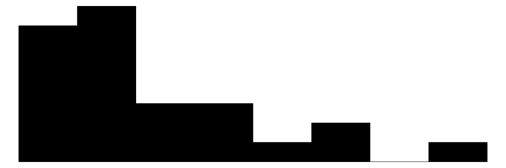

```r
peake |> modelsummary::datasummary_skim()
```

# 4 Exploratory data analysis

When exploring these data as part of a frequentist analysis, exploratory data analysis revealed that the both the response (counds of individuals) and predictor (mussel clump area) were skewed and the relationship between raw counds and mussel clump area was not linear. Furthermore, there was strong evidence of a relationship between mean and variance. Normalising both reponse and predictor addressed these issues. However, rather than log transform the response, it was considered more appropriate to model against a distribution that used a logarithmic link function.

The individual observations here ($y_i$) are the observed number of (non mussel individuals found in mussel clump $i$. As a count, these might be expected to follow a Poisson (or perhaps negative binomial) distribution. In the case of a negative binomial, the observed count for any given mussel clump area are expected to be drawn from a negative binomial distribution with a mean of $\lambda_i$. All the negative binomial distributions are expected to share the same degree of dispersion ($\theta$) - that is, the degree to which the inhabitants of mussell clumps aggregate together (or any other reason for overdispersion) is independent of mussel clump area and can be estimated as a constant across all populations.

The natural log of the expected values ($\lambda_i$) is modelled against a linear predictor that includes an intercept ($\beta_0$) and a slope ($\beta_1$) associated with the natural log of mussel area.

The priors on $\beta_0$ and $\beta_1$ should be on the natura log scale (since this will be the scale of the parameters). As starting points, we will consider the following priors:

Model formula:
$$\begin{align}
y_i &\sim{} \mathcal{Pois}(\lambda_i)\\
OR\\
y_i &\sim{} \mathcal{NB}(\lambda_i, \theta)\\
ln(\lambda_i) &= \beta_0 + \beta_1 ln(x_i)\\
\beta_0 & \sim\mathcal{N}(6,1.1)\\
\beta_1 & \sim\mathcal{N}(0,1.1)\\
OR\\
\theta &\sim{} \mathcal{\Gamma}(0.01, 0.01)\\
\end{align}$$

**Scatterplot**

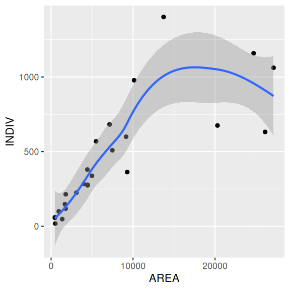

```r
ggplot(peake, aes(y = INDIV, x = AREA)) +
  geom_point() +
  geom_smooth()
```

**Conclusions:**

**Boxplots**

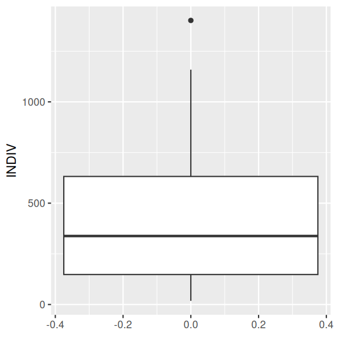

```r
ggplot(peake, aes(y = INDIV)) +
  geom_boxplot()
```

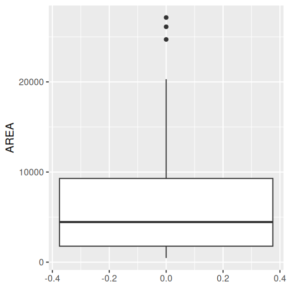

```r
ggplot(peake, aes(y = AREA)) +
  geom_boxplot()
```

**Conclusions:**

- indeed both the response (`INDIV`) and predictor (`AREA`) appear to be skewed. It is not surprising that the response is skewed as it represents counts of the number of individuals. We might expect that this should follow a Poisson distribution. Poisson distributions must be bounded by 0 at the lower end and hence as the expected value (=mean and location) of a Poisson distribution approaches 0, the distribution will become more and more asymmetrical. A the same time, the distribution would be expected to become narrower (have a smaller variance) - since in a Poisson distribution the mean and variance are equal.

Along with modelling these data against a Poisson distribution (with a natural log link), we should probably attempt to normalise the predictor variable (`AREA`). Whilst linear models don’t assume that the predictor variable follows a normal distribution (it is typically assumed to be a uniform distribution), it is assumed to be symmetrical. In this case, a natural log transformation might help achieve this. At the same time, it might also help homogeneity of variance and linearity.

We can mimic the action of using a log link and log-transformed predictor by presenting the scatterplot on log-transformed axes.

**Scatterplot**

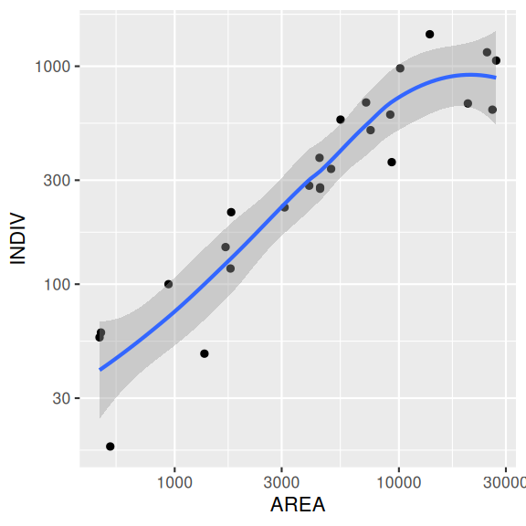

```r
ggplot(peake, aes(y = INDIV, x = AREA)) +
  geom_point() +
  geom_smooth() +
  scale_y_log10() +
  scale_x_log10()
```

**Conclusions:**

- there is no obvious violations of the assumptions now.

# 5 Fit the model

**frequentist**

```r
summary(glm(INDIV ~ log(AREA), data = peake, family = poisson()))
```

```
Call:
glm(formula = INDIV ~ log(AREA), family = poisson(), data = peake)

Coefficients:
            Estimate Std. Error z value Pr(>|z|)
(Intercept) 0.013528   0.091147   0.148    0.882
log(AREA)   0.691628   0.009866  70.100   <2e-16 ***
---
Signif. codes:  0 '***' 0.001 '**' 0.01 '*' 0.05 '.' 0.1 ' ' 1

(Dispersion parameter for poisson family taken to be 1)

    Null deviance: 7494.5  on 24  degrees of freedom
Residual deviance: 1547.8  on 23  degrees of freedom
AIC: 1738.9

Number of Fisher Scoring iterations: 4
```

```r
summary(MASS::glm.nb(INDIV ~ log(AREA), data = peake))
```

```
Call:
MASS::glm.nb(formula = INDIV ~ log(AREA), data = peake, init.theta = 7.369263003,
    link = log)

Coefficients:
            Estimate Std. Error z value Pr(>|z|)
(Intercept) -1.16452    0.53387  -2.181   0.0292 *
log(AREA)    0.82469    0.06295  13.102   <2e-16 ***
---
Signif. codes:  0 '***' 0.001 '**' 0.01 '*' 0.05 '.' 0.1 ' ' 1

(Dispersion parameter for Negative Binomial(7.3693) family taken to be 1)

    Null deviance: 161.076  on 24  degrees of freedom
Residual deviance:  25.941  on 23  degrees of freedom
AIC: 312.16

Number of Fisher Scoring iterations: 1

              Theta:  7.37
          Std. Err.:  2.16

 2 x log-likelihood:  -306.16
```

**rstanarm**

**Using default priors**

In `rstanarm`, the default priors are designed to be weakly informative. They are chosen to provide moderate regularlization (to help prevent overfitting) and help stabalise the computations.

```r
peake_rstanarm <- stan_glm(INDIV ~ log(AREA),
  data = peake,
  family = poisson(),
  iter = 5000, warmup = 1000,
  chains = 3, thin = 5, refresh = 0
)
```

```r
prior_summary(peake_rstanarm)
```

```
Priors for model 'peake_rstanarm'
------
Intercept (after predictors centered)
 ~ normal(location = 0, scale = 2.5)

Coefficients
  Specified prior:
    ~ normal(location = 0, scale = 2.5)
  Adjusted prior:
    ~ normal(location = 0, scale = 2)
------
See help('prior_summary.stanreg') for more details
```

This tells us:

- for the intercept, it is using a normal prior with a mean of 0 and a standard deviation of 2.5. The are the defaults for all non-Gaussian intercepts.
- for the coefficients (in this case, just the slope), the default prior is a normal prior centered around 0 with a standard deviation of 2.5. For Poisson models, this is then adjusted for the scale of the data by dividing the 2.5 by the standard deviation of the (in this case log) predictor (then rounded).

```r
2.5 / sd(log(peake$AREA))
```

```
[1] 2.025039
```

- there is no auxillary parameter and thus there is no auxillary prior

**Assessing priors**

One way to assess the priors is to have the MCMC sampler sample purely from the prior predictive distribution without conditioning on the observed data. Doing so provides a glimpse at the range of predictions possible under the priors. On the one hand, wide ranging preditions would ensure that the priors are unlikely to influence the actual preditions once they are conditioned on the data. On the other hand, if they are too wide, the sampler is being permitted to traverse into regions of parameter space that are not logically possible in the context of the actual underlying ecological context. Not only could this mean that illogical parameter estimates are possible, when the sampler is traversing regions of paramter space that are not supported by the actual data, the sampler can become unstable and have difficulty.

We can draw from the prior predictive distribution instead of conditioning on the response, by updating the model and indicating `prior_PD=TRUE`. After refittin the model in this way, we can plot the predictions to gain insights into the range of predictions supported by the priors alone.

```r
peake_rstanarm1 <- update(peake_rstanarm, prior_PD = TRUE)
```

```
Data points may overlap. Use the `jitter` argument to add some amount of
  random variation to the location of data points and avoid overplotting.
```

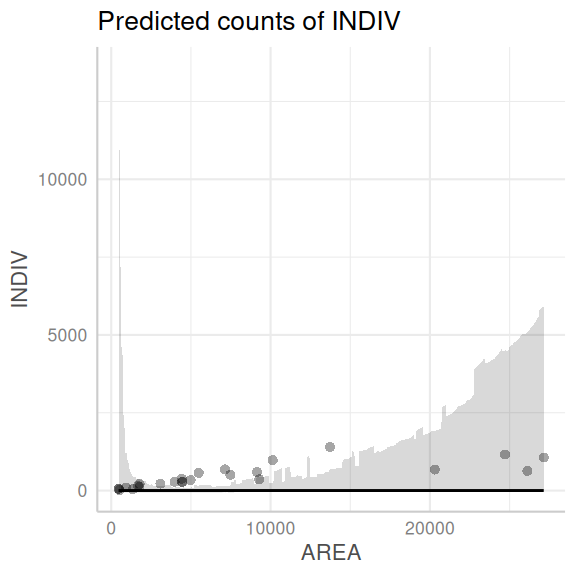

```r
ggemmeans(peake_rstanarm1, ~AREA) |> plot(show_data = TRUE)
```

```
Data points may overlap. Use the `jitter` argument to add some amount of
  random variation to the location of data points and avoid overplotting.
```

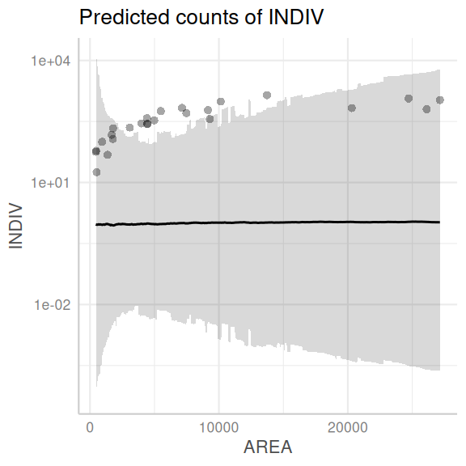

```r
ggemmeans(peake_rstanarm1, ~AREA) |> plot(jitter = FALSE, show_data = TRUE) + scale_y_log10()
```

**Conclusions:**

- we see that although the range of predictions are very wide and the slope could range from strongly negative to strongly positive, the choice to have the intercept prior have a mean of 0 results in most of the prior-only posterior draws being dramatically lower than the observed values - indeed some observed values are above the range of the prior-posterior predictions.

**Defining priors**

The following link provides some guidance about defining priors. [https://github.com/stan-dev/stan/wiki/Prior-Choice-Recommendations]

When defining our own priors, we typically do not want them to be scaled.

If we wanted to define our own priors that were less vague, yet still not likely to bias the outcomes, we could try the following priors (mainly plucket out of thin air):

I will also overlay the raw data for comparison.

```r
peake_rstanarm2 <- stan_glm(INDIV ~ log(AREA),
  data = peake,
  family = poisson(),
  prior_intercept = normal(6, 2.8, autoscale = FALSE),
  prior = normal(0, 2.3, autoscale = FALSE),
  prior_PD = TRUE,
  iter = 5000, warmup = 1000,
  chains = 3, thin = 5, refresh = 0
)
```

```
Data points may overlap. Use the `jitter` argument to add some amount of
  random variation to the location of data points and avoid overplotting.
```

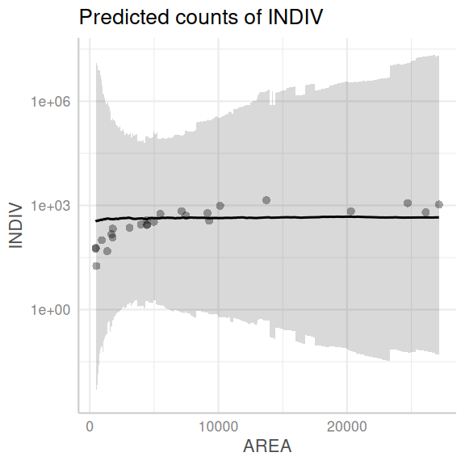

```r
ggemmeans(peake_rstanarm2, ~AREA) |>
  plot(show_data = TRUE) +
  scale_y_log10()
```

Now lets refit, conditioning on the data.

```r
peake_rstanarm3 <- update(peake_rstanarm2, prior_PD = FALSE)
```

**Plotting prior and posterior**

```
Drawing from prior...
```

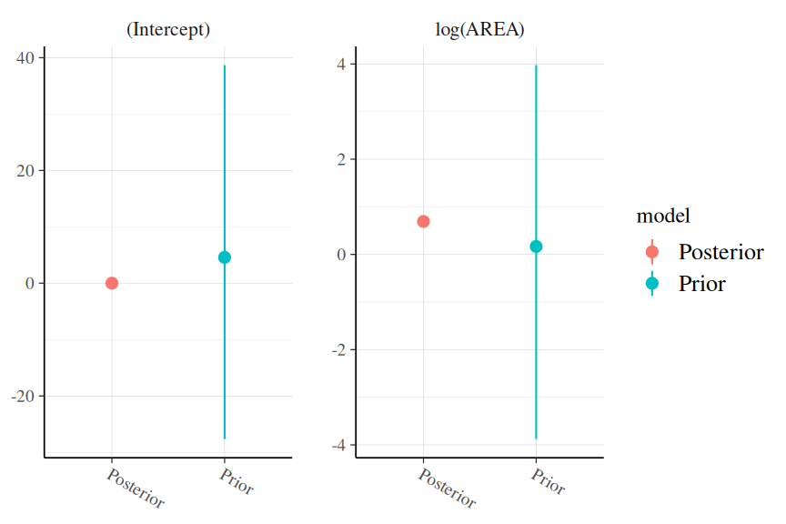

```r
posterior_vs_prior(peake_rstanarm3,
  color_by = "vs", group_by = TRUE,
  facet_args = list(scales = "free_y")
)
```

**Conclusions:**

- in each case, the prior is substantially wider than the posterior, suggesting that the posterior is not biased towards the prior.

```
Data points may overlap. Use the `jitter` argument to add some amount of
  random variation to the location of data points and avoid overplotting.
```

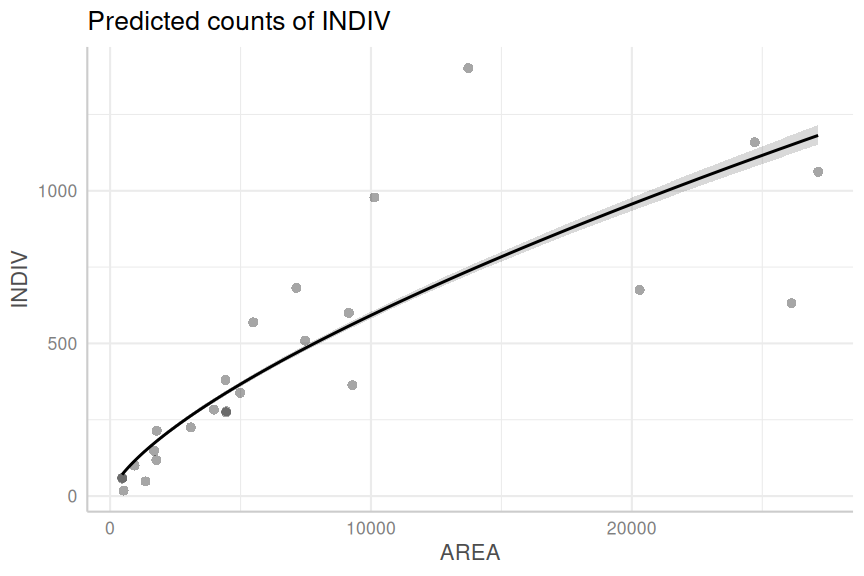

```r
ggemmeans(peake_rstanarm3, ~AREA) |> plot(show_data = TRUE)
```

**brms**

**Using default priors**

In `brms`, the default priors are designed to be weakly informative. They are chosen to provide moderate regularlization (to help prevent overfitting) and help stabalise the computations.

Unlike `rstanarm`, `brms` models must be compiled before they start sampling. For most models, the compilation of the stan code takes around 45 seconds.

```r
peake_form <- bf(INDIV ~ scale(log(AREA)), family = poisson())
peake_brm <- brm(peake_form,
  data = peake,
  iter = 5000, warmup = 1000,
  chains = 3, cores = 3,
  thin = 5, refresh = 0,
  backend = "rstan"
)
```

```r
prior_summary(peake_brm)
```

```
                  prior     class         coef group resp dpar nlpar lb ub       source
                 (flat)         b                                               default
                 (flat)         b scalelogAREA                             (vectorized)
 student_t(3, 5.8, 2.5) Intercept                                               default
```

This tells us:

- for the intercept, it is using a student t (flatter normal) prior with a mean of 5.8 and a standard deviation of 2.5. The mean of this prior is based on the median of the log-transformed response and the standard deviation of 2.5 is the default minimum.

[output not shown]

```r
mad(log(peake$INDIV))
```

```
[1] 1.025465
```

**Assessing priors**

One way to assess the priors is to have the MCMC sampler sample purely from the prior predictive distribution without conditioning on the observed data. Doing so provides a glimpse at the range of predictions possible under the priors. On the one hand, wide ranging preditions would ensure that the priors are unlikely to influence the actual preditions once they are conditioned on the data. On the other hand, if they are too wide, the sampler is being permitted to traverse into regions of parameter space that are not logically possible in the context of the actual underlying ecological context. Not only could this mean that illogical parameter estimates are possible, when the sampler is traversing regions of paramter space that are not supported by the actual data, the sampler can become unstable and have difficulty.

In `brms`, we can inform the sampler to draw from the prior predictive distribution instead of conditioning on the response, by running the model with the `sample_prior='only'` argument. Unfortunately, this cannot be applied when there are flat priors (since the posteriors will necessarily extend to negative and positive infinity). Therefore, in order to use this useful routine, we need to make sure that we have defined a proper prior for all parameters.

We will adopt a similar approach to that of `rstanarm` - that is if we DO NOT scale the predictor, then we would use `2.5 * sd(log(peake$INDIV))/sd(log(peake$AREA))` (approx. 2.3). If we do scale the predictor (good practice for Bayesian models), then we would use `2.5 * sd(log(peake$INDIV))/1` (approx. 2.8)

```r
peake_form <- bf(INDIV ~ scale(log(AREA)), family = poisson())
peake_brm1 <- brm(peake_form,
  data = peake,
  prior = c(
    prior(normal(0, 2.8), class = "b")
  ),
  sample_prior = "only",
  iter = 5000, warmup = 1000,
  chains = 3, cores = 3,
  thin = 5, refresh = 0,
  backend = "rstan"
)
```

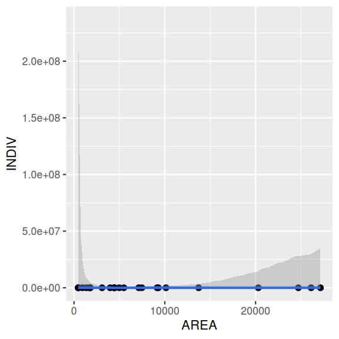

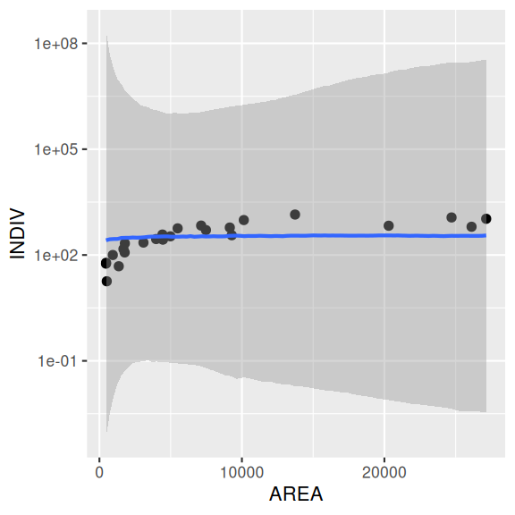

```r
peake_brm1 |>
  conditional_effects() |>
  plot(points = TRUE) |>
  _[[1]] + scale_y_log10()
```

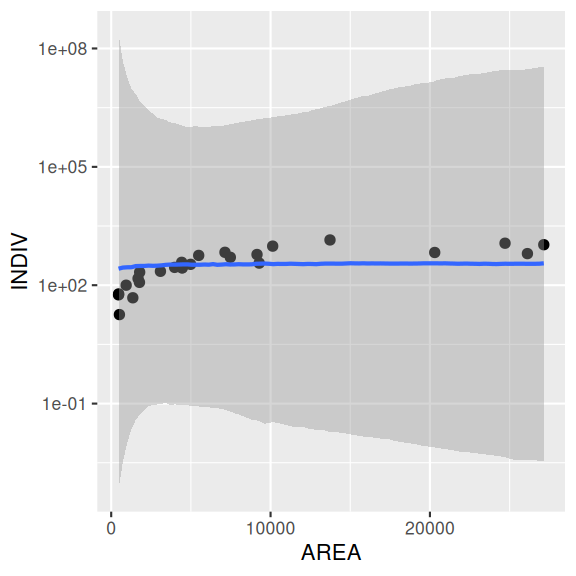

```r
# OR
plot(conditional_effects(peake_brm1), points = TRUE, plot = FALSE)[[1]] + scale_y_log10()
```

```
Data points may overlap. Use the `jitter` argument to add some amount of
  random variation to the location of data points and avoid overplotting.
```

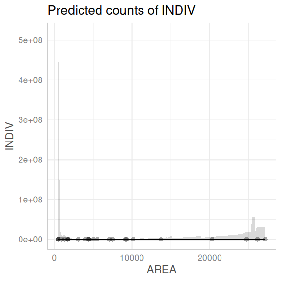

```r
ggemmeans(peake_brm1, ~AREA) |> plot(show_data = TRUE)
```

```
Data points may overlap. Use the `jitter` argument to add some amount of
  random variation to the location of data points and avoid overplotting.
```

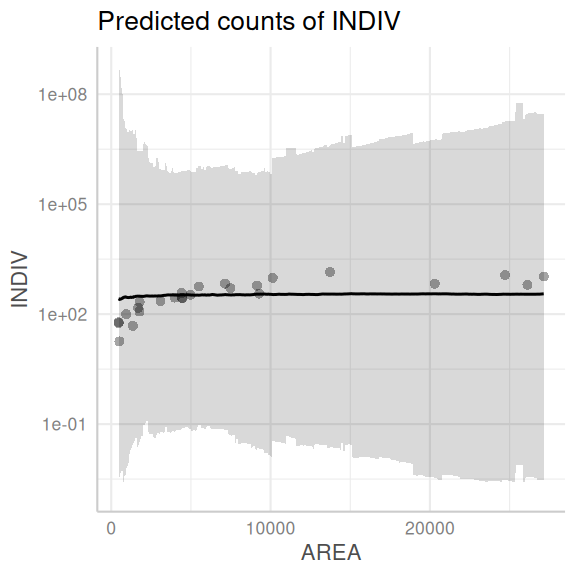

```r
ggemmeans(peake_brm1, ~AREA) |> plot(show_data = TRUE) + scale_y_log10()
```

**Conclusions:**

- we see that the range of predictions is faily wide and the slope could range from strongly negative to strongly positive.

**Defining priors**

The following link provides some guidance about defining priors. [https://github.com/stan-dev/stan/wiki/Prior-Choice-Recommendations]

When defining our own priors, we typically do not want them to be scaled.

If we wanted to define our own priors that were less vague, yet still not likely to bias the outcomes, we could try the following priors (mainly plucket out of thin air):

I will also overlay the raw data for comparison.

```r
peake_form <- bf(INDIV ~ scale(log(AREA)), family = poisson())
priors <- prior(normal(6, 1.1), class = "Intercept") +
  prior(normal(0, 1.1), class = "b")
peake_brm2 <- brm(peake_form,
  data = peake,
  prior = priors,
  sample_prior = "only",
  iter = 5000, warmup = 1000,
  chains = 3, cores = 3,
  thin = 5, refresh = 0,
  backend = "rstan"
)
```

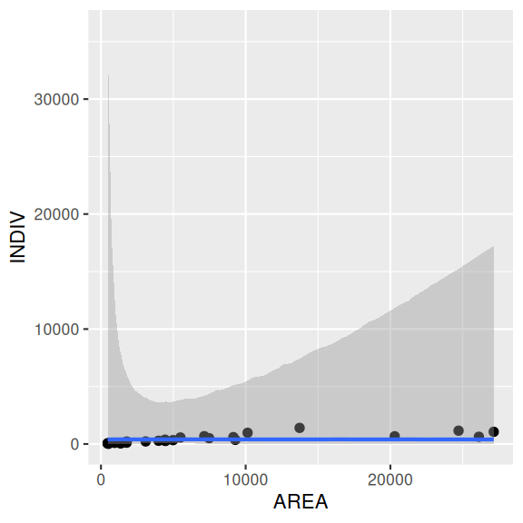

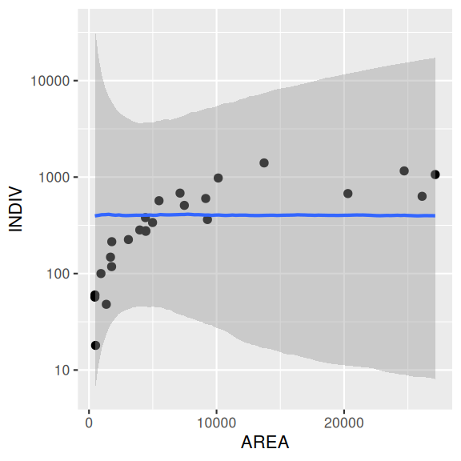

```r
peake_brm2 |>
  conditional_effects() |>
  plot(points = TRUE) |>
  _[[1]] + scale_y_log10()
```

```
Data points may overlap. Use the `jitter` argument to add some amount of
  random variation to the location of data points and avoid overplotting.
```

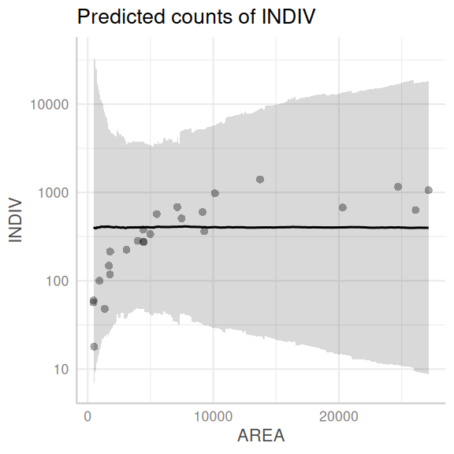

```r
ggemmeans(peake_brm2, ~AREA) |>
  plot(show_data = TRUE) +
  scale_y_log10()
```

```r
peake_brm3 <- update(peake_brm2, sample_prior = TRUE, refresh = 0)
```

```
The desired updates require recompiling the model
```

**Plotting prior and posterior**

```r
peake_brm3 |> get_variables()
```

```
 [1] "b_Intercept"     "b_scalelogAREA"  "Intercept"       "prior_Intercept"
 [5] "prior_b"         "lprior"          "lp__"            "accept_stat__"
 [9] "stepsize__"      "treedepth__"     "n_leapfrog__"    "divergent__"
[13] "energy__"
```

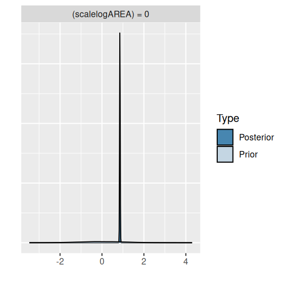

```r
peake_brm3 |>
  hypothesis("scalelogAREA=0") |>
  plot()
```

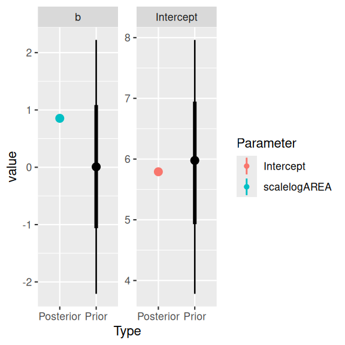

```r
peake_brm3 |> SUYR_prior_and_posterior()
```

**Exploring the stan code**

```r
standata(peake_brm3)
```

```
$N
[1] 25

$Y
 [1]   18   60   57  100   48  118  148  214  225  283  380  278  338  274  569
[16]  509  682  600  978  363 1402  675 1159 1062  632

$K
[1] 2

$Kc
[1] 1

$X
   Intercept scalelogAREA
1          1  -1.70743026
2          1  -1.78468638
3          1  -1.79653272
4          1  -1.22281190
5          1  -0.92411634
6          1  -0.70730890
7          1  -0.74836084
8          1  -0.70156133
9          1  -0.25762985
10         1  -0.05260010
11         1   0.03319851
12         1   0.03809703
13         1   0.12940888
14         1   0.03794781
15         1   0.20802333
16         1   0.45804518
17         1   0.42063988
18         1   0.62168564
19         1   0.70435343
20         1   0.63378934
21         1   0.95036778
22         1   1.26719650
23         1   1.42649361
24         1   1.50250471
25         1   1.47128697
attr(,"assign")
[1] 0 1

$prior_only
[1] 0

attr(,"class")
[1] "standata" "list"
```

```r
stancode(peake_brm3)
```

```
// generated with brms 2.22.0
functions {
}
data {
  int<lower=1> N;  // total number of observations
  array[N] int Y;  // response variable
  int<lower=1> K;  // number of population-level effects
  matrix[N, K] X;  // population-level design matrix
  int<lower=1> Kc;  // number of population-level effects after centering
  int prior_only;  // should the likelihood be ignored?
}
transformed data {
  matrix[N, Kc] Xc;  // centered version of X without an intercept
  vector[Kc] means_X;  // column means of X before centering
  for (i in 2:K) {
    means_X[i - 1] = mean(X[, i]);
    Xc[, i - 1] = X[, i] - means_X[i - 1];
  }
}
parameters {
  vector[Kc] b;  // regression coefficients
  real Intercept;  // temporary intercept for centered predictors
}
transformed parameters {
  real lprior = 0;  // prior contributions to the log posterior
  lprior += normal_lpdf(b | 0, 1.1);
  lprior += normal_lpdf(Intercept | 6, 1.1);
}
model {
  // likelihood including constants
  if (!prior_only) {
    target += poisson_log_glm_lpmf(Y | Xc, Intercept, b);
  }
  // priors including constants
  target += lprior;
}
generated quantities {
  // actual population-level intercept
  real b_Intercept = Intercept - dot_product(means_X, b);
  // additionally sample draws from priors
  real prior_b = normal_rng(0,1.1);
  real prior_Intercept = normal_rng(6,1.1);
}
```

# 6 MCMC sampling diagnostics

**rstanarm**

**bayesplot**

The `bayesplot` package offers a range of MCMC diagnostics as well as Posterior Probability Checks (PPC), all of which have a convenient `plot()` interface. Lets start with the MCMC diagnostics.

**See list of available diagnostics by name**

```r
available_mcmc()
```

```
bayesplot MCMC module:
  mcmc_acf
  mcmc_acf_bar
  mcmc_areas
  mcmc_areas_ridges
  mcmc_combo
  mcmc_dens
  mcmc_dens_chains
  mcmc_dens_overlay
  mcmc_hex
  mcmc_hist
  mcmc_hist_by_chain
  mcmc_intervals
  mcmc_neff
  mcmc_neff_hist
  mcmc_nuts_acceptance
  mcmc_nuts_divergence
  mcmc_nuts_energy
  mcmc_nuts_stepsize
  mcmc_nuts_treedepth
  mcmc_pairs
  mcmc_parcoord
  mcmc_rank_ecdf
  mcmc_rank_hist
  mcmc_rank_overlay
  mcmc_recover_hist
  mcmc_recover_intervals
  mcmc_recover_scatter
  mcmc_rhat
  mcmc_rhat_hist
  mcmc_scatter
  mcmc_trace
  mcmc_trace_highlight
  mcmc_violin
```

Of these, we will focus on:

- mcmc_trace: this plots the estimates of each parameter over the post-warmup length of each MCMC chain. Each chain is plotted in a different shade of blue, with each parameter in its own facet. Ideally, each **trace** should just look like noise without any discernible drift and each of the traces for a specific parameter should look the same (i.e, should not be displaced above or below any other trace for that parameter).

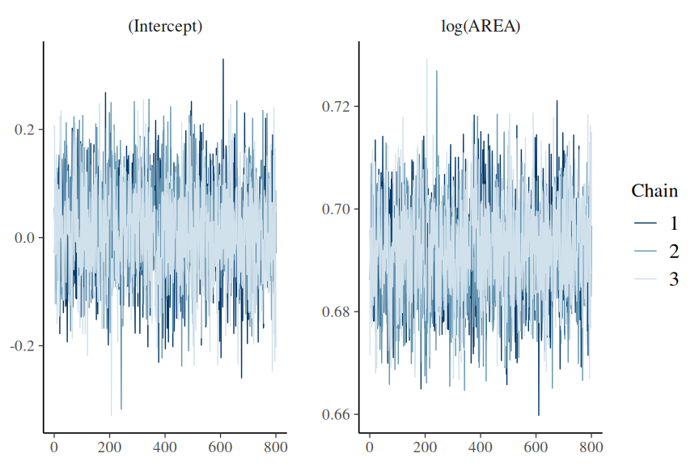

```r
plot(peake_rstanarm3, plotfun = "mcmc_trace")
```

The chains appear well mixed and very similar

- acf (autocorrelation function): plots the autocorrelation between successive MCMC sample lags for each parameter and each chain

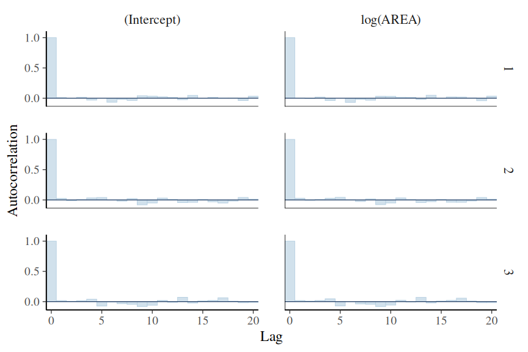

```r
plot(peake_rstanarm3, "acf_bar")
```

There is no evidence of autocorrelation in the MCMC samples

- Rhat: Rhat is a measure of convergence between the chains. The closer the values are to 1, the more the chains have converged. Values greater than 1.05 indicate a lack of convergence. There will be an Rhat value for each parameter estimated.

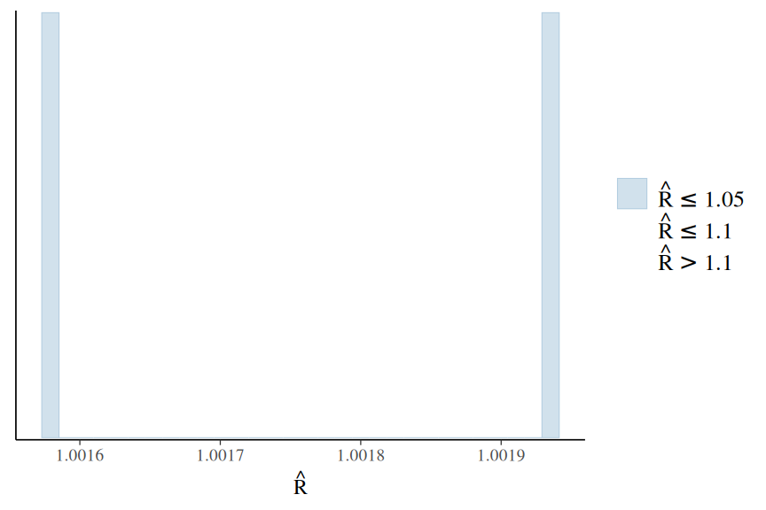

```r
plot(peake_rstanarm3, "rhat_hist")
```

All Rhat values are below 1.05, suggesting the chains have converged.

- neff (number of effective samples): the ratio of the number of effective samples (those not rejected by the sampler) to the number of samples provides an indication of the effectiveness (and efficiency) of the MCMC sampler. Ratios that are less than 0.5 for a parameter suggest that the sampler spent considerable time in difficult areas of the sampling domain and rejected more than half of the samples (replacing them with the previous effective sample).

  If the ratios are low, tightening the priors may help.

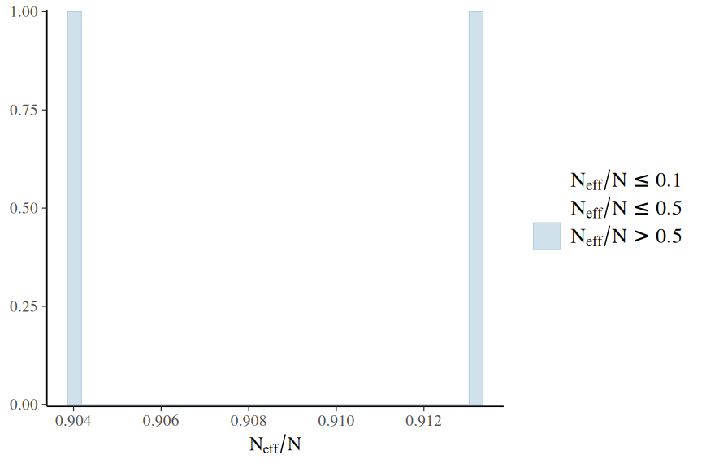

```r
plot(peake_rstanarm3, "neff_hist")
```

Ratios all very high.

**More diagnostics**

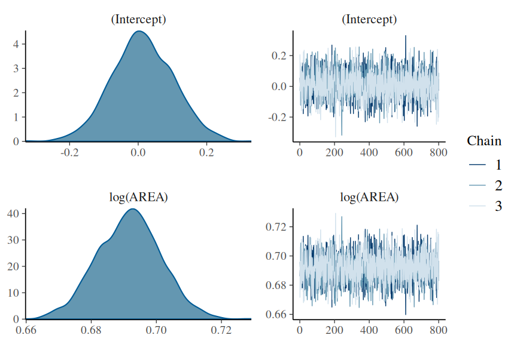

```r
plot(peake_rstanarm3, "combo")
```

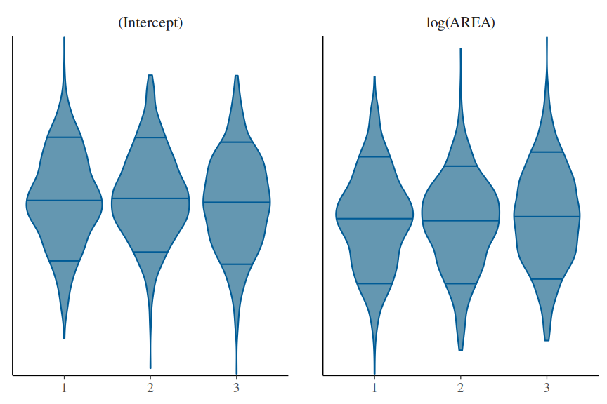

```r
plot(peake_rstanarm3, "violin")
```

**stan plots**

The `rstan` package offers a range of MCMC diagnostics. Lets start with the MCMC diagnostics.

Of these, we will focus on:

- stan_trace: this plots the estimates of each parameter over the post-warmup length of each MCMC chain. Each chain is plotted in a different colour, with each parameter in its own facet. Ideally, each **trace** should just look like noise without any discernible drift and each of the traces for a specific parameter should look the same (i.e, should not be displaced above or below any other trace for that parameter).

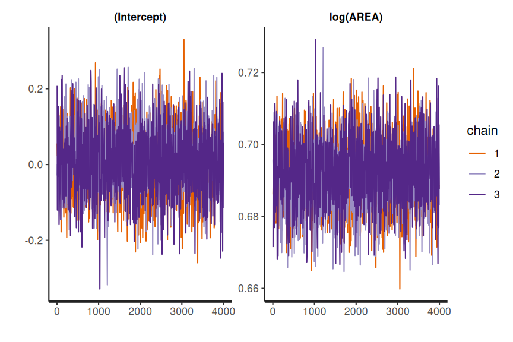

```r
stan_trace(peake_rstanarm3)
```

The chains appear well mixed and very similar

- stan_acf (autocorrelation function): plots the autocorrelation between successive MCMC sample lags for each parameter and each chain

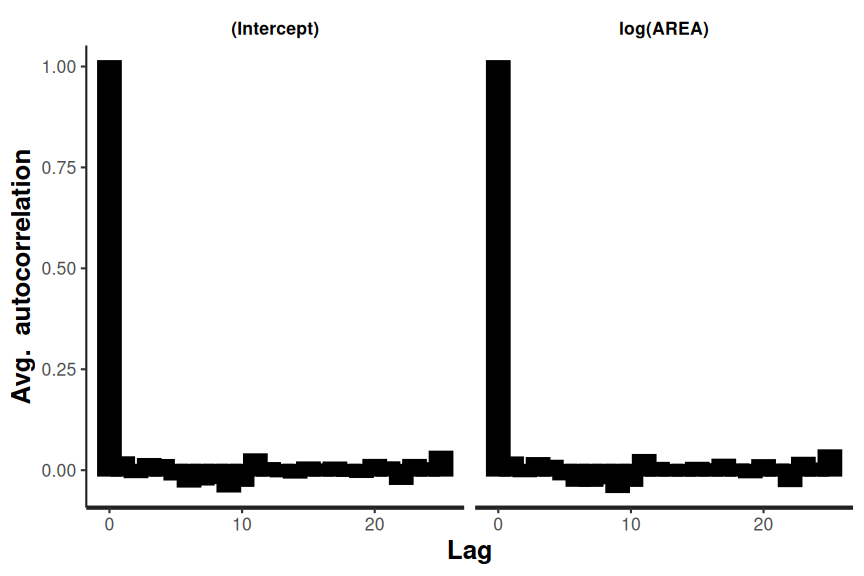

```r
stan_ac(peake_rstanarm3)
```

There is no evidence of autocorrelation in the MCMC samples

- stan_rhat: Rhat is a **scale reduction factor** measure of convergence between the chains. The closer the values are to 1, the more the chains have converged. Values greater than 1.05 indicate a lack of convergence. There will be an Rhat value for each parameter estimated.

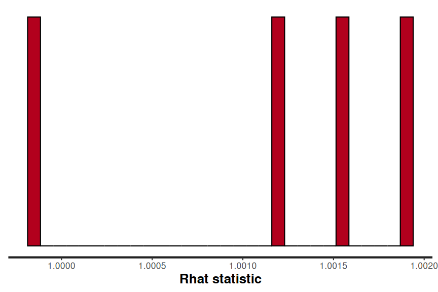

```r
stan_rhat(peake_rstanarm3)
```

All Rhat values are below 1.05, suggesting the chains have converged.